# “Trabajo prácico Estadistica II”

## Subtitulo: Educación y pobreza. Tópicos en disputa.

### Autores: *Goggi Dolores* (45295589), *García Lara* (44897819).

### Fecha: 13/07/2024.

Nuestro trabajo plantea el análisis de dos variables que pueden relacionarse en el contexto actual: educación y pobreza. A partir de ello intentamos observar que problemática es mas relevante para la ciudadanía donde ambas variables son un punto clave de opinión publica en estos momentos.

Para realizar este análisis tuvimos en cuenta la media, la desviación estandar, el valor de la muestra seleccionada a partir de una encuesta de forma aleatoria. Por otro lado, a partir de los datos obtenidos construímos los intervalos de confianza correspondientes a cada variable.

```r
mean(datos$problemas_educacion)
```

```
## [1] 8.571892
```

```r
sd(datos$problemas_educacion)
```

```
## [1] 1.872121
```

```r
nrow(datos)
```

```
## [1] 925
```

```r
ci(datos$problemas_educacion, confidence=0.95)
```

```
##   Estimate   CI lower   CI upper Std. Error
## 8.57189189 8.45108815 8.69269563 0.06155496
```

En este primer caso, obtuvimos una media de 8.571892 que se corresponde con el promedio de la población que respondió al interrogante de la variable. En segundo lugar el calculo de la desviación estandar dio como resultado 1.872121 que son los valores que se alejan del promedio. Por último obtuvimos una población total de 925 personas. Teniendo en cuenta estos datos, armamos los intervalos de confianza en donde se estima un 95% de confianza de que el intervalo (8.45-8.69) contiene el promedio de la valoración de la educacion.

```r
mean(datos$problemas_pobreza)
```

```
## [1] 8.637838
```

```r
sd(datos$problemas_pobreza)
```

```
## [1] 1.745023
```

```r
nrow(datos)
```

```
## [1] 925
```

```r
ci(datos$problemas_pobreza, confidende=0.95)
```

```
##   Estimate   CI lower   CI upper Std. Error
## 8.63783784 8.52523547 8.75044020 0.05737599
```

En este segundo caso, obtuvimos una media de 8.637838 que se corresponde con el promedio de la población que respondió al interrogante de la variable. En segundo lugar el calculo de la desviación estandar dio como resultado 1.745023 que son los valores que se alejan del promedio. Por último obtuvimos una población total de 925 personas. Teniendo en cuenta estos datos, armamos los intervalos de confianza en donde se estima un 95% de confianza de que el intervalo (8.52-8.75 contiene el promedio de la valoración de la pobreza.

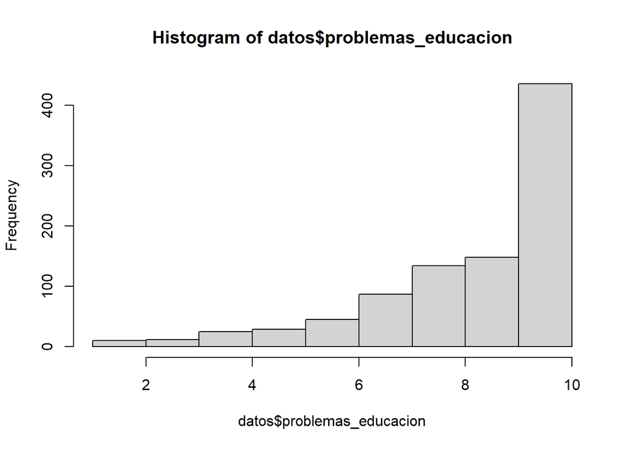

```r
hist(datos$problemas_educacion)
```

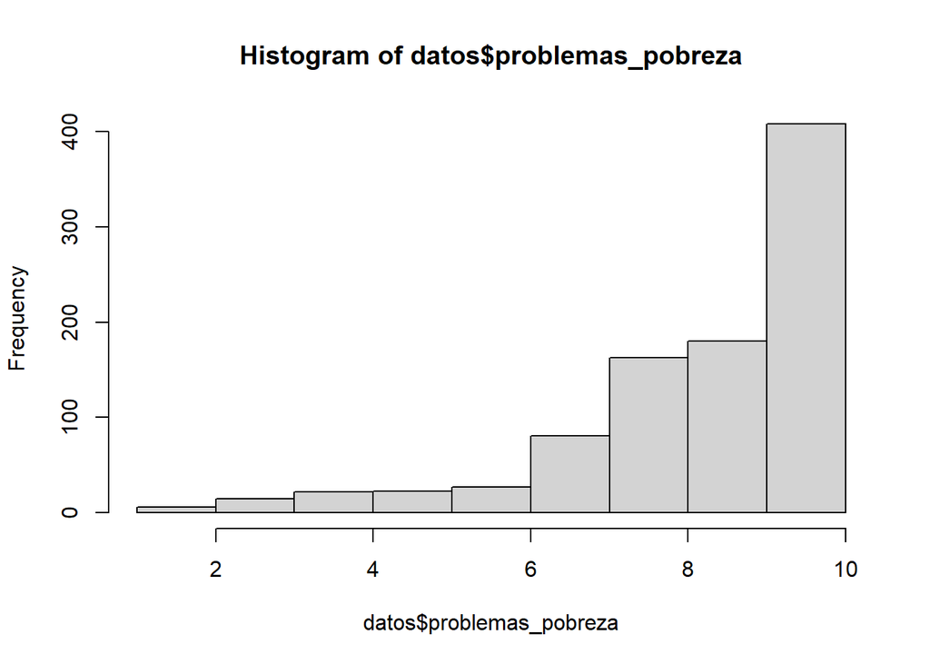

```r
hist(datos$problemas_pobreza)
```

A partir de los histogramas denotamos que ambos problemas tienen una amplia relevancia en cuanto a su problematizacion en la esfera publica. Por esto decidimos realizar un calculo del coeficiente de correlacion de pearson para demostrar la relacion entre ambas variables.

```r
cor(datos$problemas_educacion, datos$problemas_pobreza)
```

```
## [1] 0.5527657
```

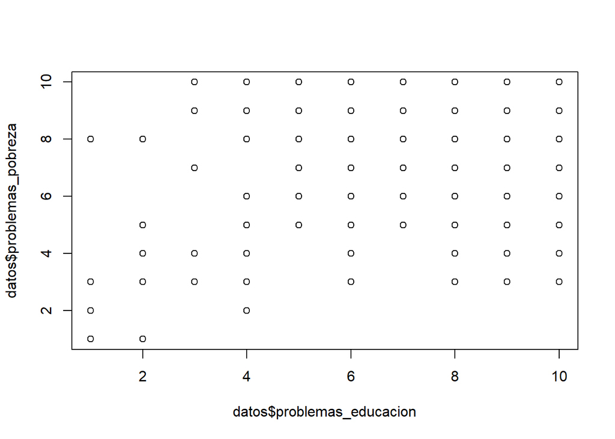

```r
plot(datos$problemas_educacion, datos$problemas_pobreza)
```

```r
ci(datos$problemas_educacion, confidence=0.99)
```

```
##   Estimate   CI lower   CI upper Std. Error
## 8.57189189 8.41300866 8.73077512 0.06155496
```

En el primer caso, hay un 99% de confianza de que el intervalo (8.41-8.73) contiene el promedio de respuestas de sobre la educación en cuanto problema.

```r
ci(datos$problemas_pobreza, confidence=0.99)
```

```
##   Estimate   CI lower   CI upper Std. Error
## 8.63783784 8.48974120 8.78593447 0.05737599
```

En este segundo caso, estimamos un 99% de confianza de que el intervalo (8.48- 8.78) contiene el promedio de respuestas sobre la pobreza como problema.

Ya que armamos intervalos de confianza de 95% para evaluar cada variable y visualizar la contencion de la media muestral representativa del promedio de ciudadanos que participaron en la encuesta de opinion sobre los problemas de educacion y pobreza, decidimos construir intervalos de confianza de 99% para evaluar que sucede cuando elevamos la confianza.

Como parte de la reflexión personal nos parece propicio analizar estas variables en particular dado a los planteos actuales, tanto de políticos como de ciudadanos acerca de la brecha de desigualdad socioeconómica existente en el acceso a los distintos niveles educativos. Esta situación propicia que, aquellos que provienen de un estrato socioeconómico menor tengan dificultades, según lo expresado en discursos, en cuanto al acceso, permanencia y egreso de los jovenes en la educación obligatoria lo que conlleva a pensar que su desarollo futuro no será el mas propicio dado a los obstáculos económicos que genera que muchos de ellos o no puedan ingresar o egresarse de la universidad, acentuando consecuentemente la desigualdad de acceso de este grupo social a lo largo de su vida. De esta forma, podemos pensar en una conjunción de ambas variables, sin acceso a la educación los jovenes no tienen un futuro próspero en cuanto desarrollo profesional y laboral. Mientras que al mismo tiempo, la economía propia de cada hogar que determina su permanencia a un estrato social determinado hace que los jovenes no puedan sostener o acceder a la educación en sus diferentes esferas.